# Machine Learning with Coursera

Jae Kwan Koo

# Regularization

## The problem of overffitting

- underfitting
  - the data clearly shows structure not captured by the model.
  - Underfitting, or high bias, is when the form of our hypothesis function h maps poorly to the trend of the data.
- overfitting
  - 알고리즘이 high variance를 갖는다.

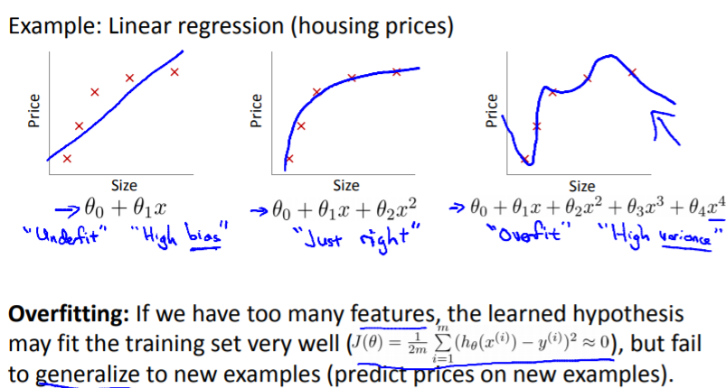

과적합은 본질적으로 오차 또는 노이즈(noise)를 너무 면밀히 추적하는 것을 의미  
과적합 상황은 바람직하지 않다. 얻어진 적합이 원래의 훈련 데이터에 속하지 않는 새로운 관측치들에 대한 반응변수를 정확하게 추정하지 못할 것이기 때문

분산이 높으면 훈련 데이터의 변화가 작아도 $\hat f$는 크게 변할 수 있다.  
일반적으로, 통계학습방법의 유연성이 높을수록 분산도 더 높다. 유연한 모형은 관측치들을 아주 잘 따라간다. 이것은 분산이 높은데, 데이터 포인트 중 어느 하나를 변화시키면 추정치 $\hat f$상당히 크게 변할 수도 있기 때문이다.

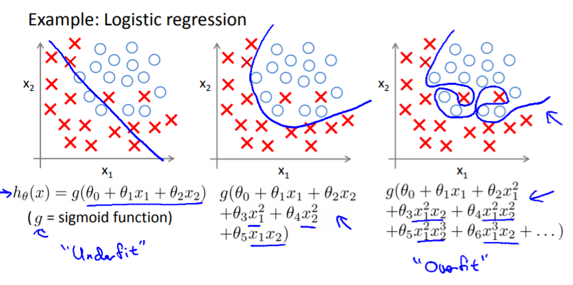

training set에만 잘 맞아 training set을 대상으로 비용함수가 거의 0이 나오고, 복잡한 모형으로 적합될 것이다. 대신 새로운 데이터에 대한 일반화가 잘 되지 못한다.

특성이 많아질수록 시각적으로 표현하기가 어렵다.  
특성 대부분이 예측에 도움이 될 것 같은데, 어떤 특성을 남겨야 할지 선택하기 어렵다.  
특성이 많은데 학습 데이터가 적은 경우 과적합 문제가 발생할 수 있다.

### How to solve?

This terminology is applied to both linear and logistic regression.  
There are two main options to address the issue of overfitting:

1. Reduce the number of features
- Manually select which features to keep.
- Use a model selection algorithm (studied later in the course).

알고리즘이 어떤 특성을 사용할 건지 자동으로 선택하거나 버릴지는 차후 모델 선택 알고리즘을 공부할 때, 자세히 살펴보자.  
단점으로는 몇 가지 특성을 버림으로 인해 문제에 포함된 정보를 같이 버리게 된다는 것.

2. Regularization(정규화)
- Keep all the features, but reduce the magnitude of parameters
- Regularization works well when we have a lot of slightly useful features.

모든 특성들을 남기되 각각의 특성이 갖는 영향 규모를 줄이는 것.  
즉, $\theta$가 미치는 영향을 줄인다.  
이 방법은 과적합 문제를 잘 해결한다.

많은 특성들이 있을 때, 그리고 각 특성들이 예측에 엄청 작은 영향을 미치는 경우를 생각해보자.  
많은 특성이 있고 각각의 특성이 예측값에 영향을 주기 때문에 특성을 버리기 싫은 것이다.

## Cost function

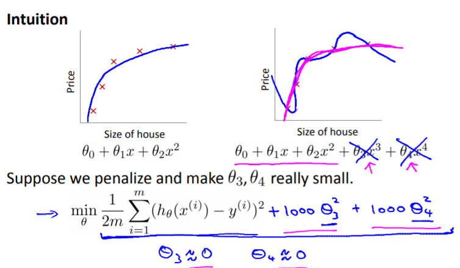

이 비용함수를 최소화해보자. 이 함수에 약간의 수정을 할 것이다.  
이제 우리가 이 함수를 최소화하려면, cost function에서의 $\theta_3$, $\theta_4$가 작게 되어야 될 것이다.  
전체 함수를 최소화하는 목적에는 변함이 없으나 따로 떼서 일부분을 keep해둔 것이라고 생각하면 나머지 부분에서 작아져야 된다.

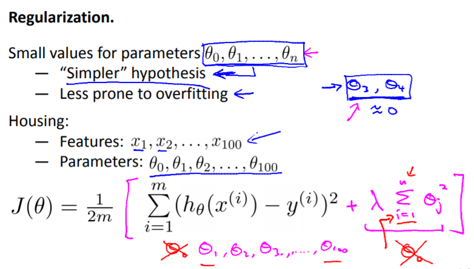

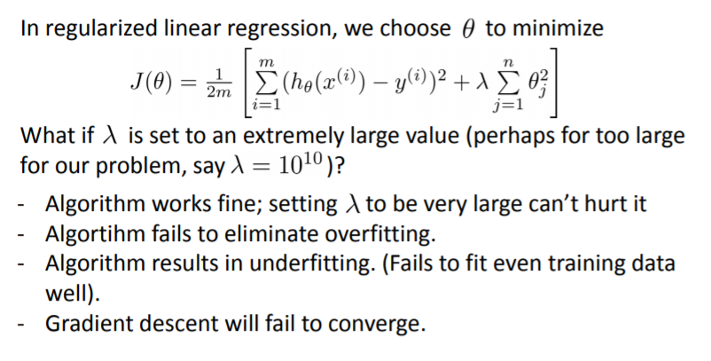

parameters들을 shrinkage하기 위한 modified cost function이다.  
편의를 위해 $\theta_0$을 제외한 1부터 summation을 하여 모수에 페널티를 주었다.

**$\lambda$ : regularization parameter**

정규화를 통해 이전보다 더 단순한 모형이 될 것이다.

만약 regularization parameter가 너무 크면 가설이 거의 0으로 되고 절편만 남게 된다. 결국 underfitting의 결과를 초래하게 될 것이다.

이후, multi-selection course에서 어떻게 regularization parameter을 잘 선택할 것인지 알아보도록 하자.

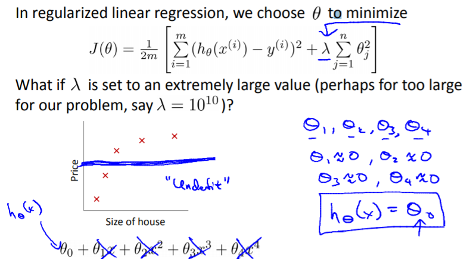

Using the above cost function with the extra summation, we can smooth the output of our hypothesis function to reduce overfitting.  
If lambda is chosen to be too large, it may smooth out the function too much and cause underfitting.

Hence, what would happen if $\lambda$ = 0 or is too small ?  
-> 초기에 설정한 cost function과 전혀 다르지 않을 것이고 과적합의 문제는 여전할 것이다.

## regularized linear regression

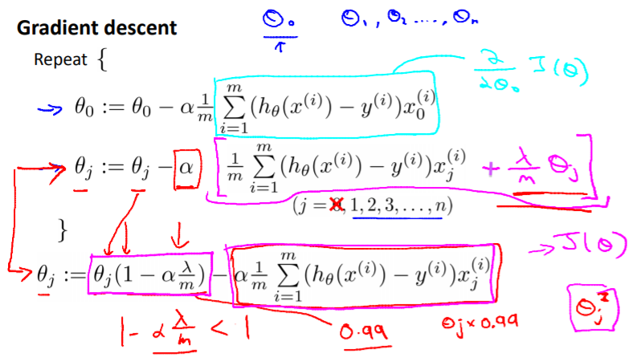

$\theta_0$만 따로 분리해서 적었다.  
분리했다고 바뀐것은 없다. 단지 $\theta_0$는 페널티를 주지않겠다는 것이다. 나머지 $\theta_1$부터 $\theta_n$까지는 페널티를 주게된다.

### Normal equation

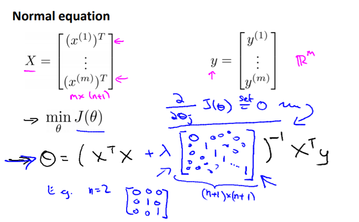

regularization을 선형모형에 적용하면 $\theta$는 위와 같이 구해줄 수 있다.

### Non-invertibility

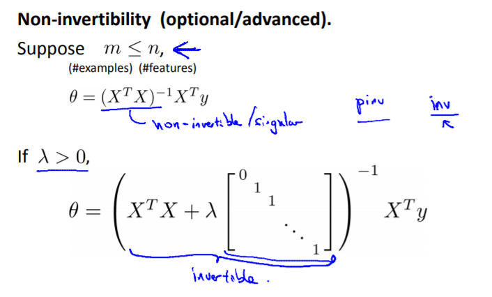

Recall that if m < n, then $(X^TX)^{-1}$ is non-invertible.  
However, when we add the term $\lambda I$, then $(X^TX+\lambda I)^{-1}$ becomes invertible.

여기서 I는 대각원소가 1인 diagonal matrix이다. 첫 모수에 대해서는 페널티를 주지 않으므로 I의 첫 대각원소는 0으로 둔다.

## Regularized logistic regression

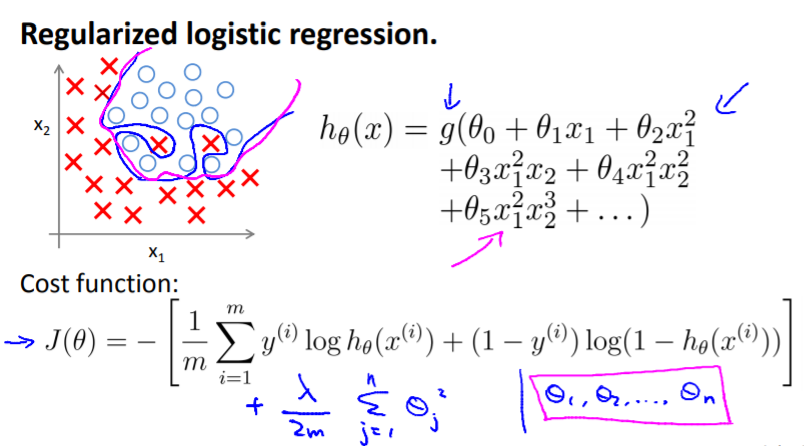

로지스틱 모형의 cost function에서 제곱항에 대해 페널티 항을 더했다.  
이제 decision boundary는 덜 유연해질 것이다.  
결과적으로, 과적합(overfitting)을 피할 수 있다.

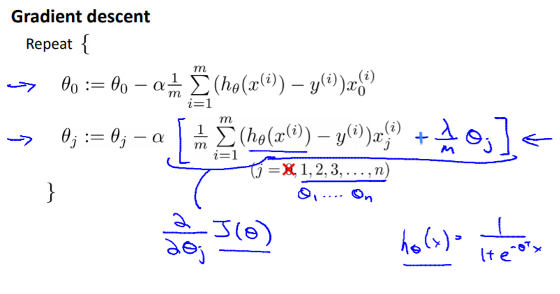

$theta_0$에 대해서는 페널티를 부과하지 않는다.

나머지에 대해 페널티를 부과한 cost function을 미분한 형태이다.

$$J(\theta)=-{1\over m}\sum_{i=1}^m[y^{(i)}log(h_\theta(x^{(i)}))+
(1-y^{(i)})log(1-h_\theta(x^{(i)}))]+
{\lambda\over2m}\sum_{j=1}^n\theta_j^2$$

## Exercise

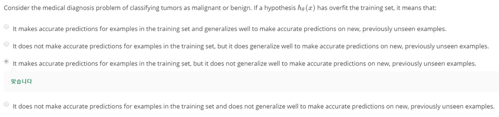

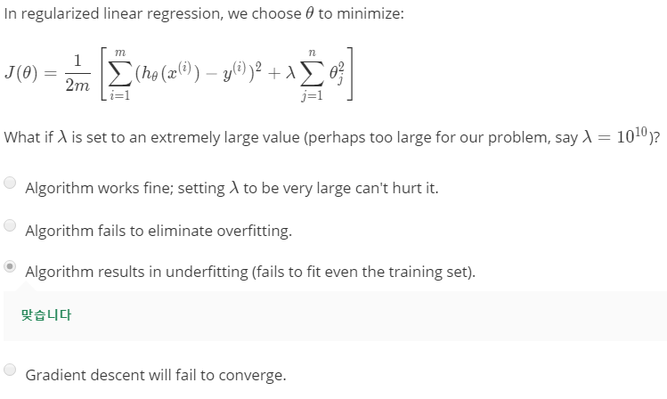

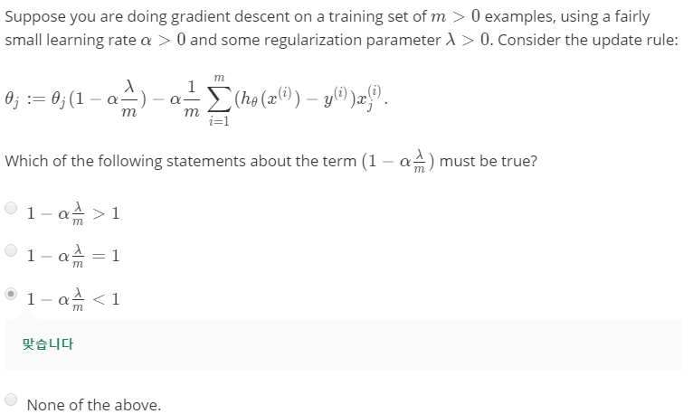

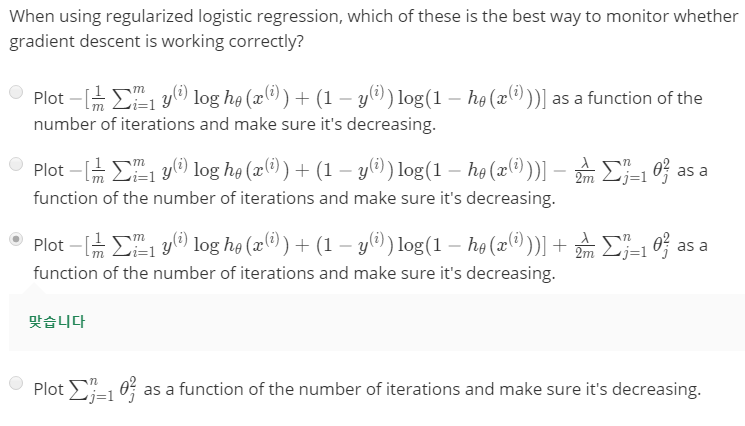

## Test

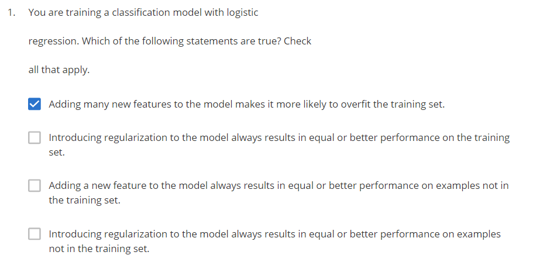

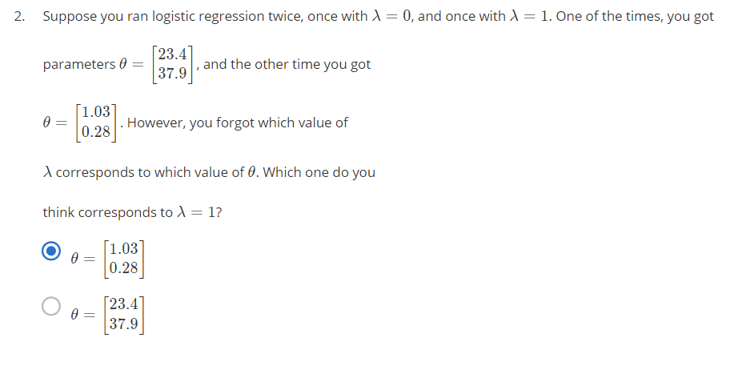

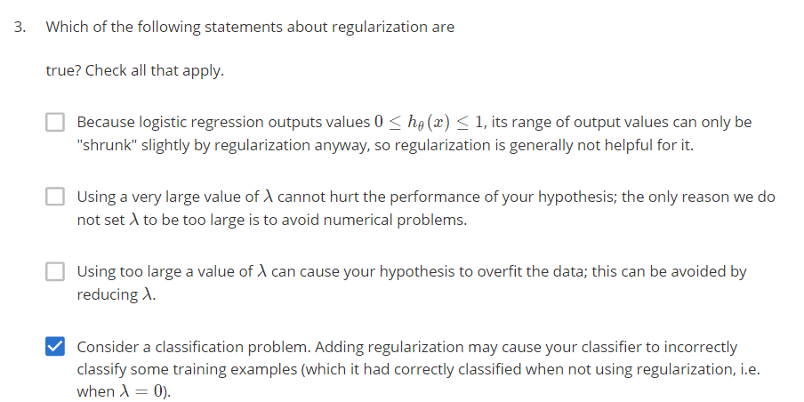